# Store Goals Analysis - Exploratory Data Analysis

# Notes

1. Aligning on Common Column Names
- STORE_NBR, STORE_NUM, STORENUM = STORE_NUMBER
- EMPLOYEE_NUM, EMPLOYEENUM = SALES_ASSOCIATE
- TXN_DATE, BUSINESSDATE = BUSINESS_DATE

```python
# Loaded variable 'df' from URI: /home/sagemaker-user/smart-goals/raw-data/Store_Sales_Goal_Data.csv
import pandas as pd
import numpy as np
import seaborn as sns
import matplotlib.pyplot as plt
from snowflake.snowpark import Session
from snowflake.snowpark import functions as F

from smart_goals.utils.data_loaders import *
import warnings

# Suppress pandas index warnings from snowflake write_pandas
warnings.filterwarnings('ignore', message='.*non-standard index.*', category=UserWarning)
```

```python
session = Session.builder.getOrCreate()
session.use_database("DEV_DS")
session.use_schema("DBT_DWERNERSEXTON")
```

```python
goal_start_date = "2025-11-01"
analysis_start_date = '2023-01-01'
associate_tenure_start_date = '2020-01-01' # Associate IDs might not exist before this.
```

```python
store_sales_goals_zipline = load_store_goals_snowpark(session)
```

```
INFO:smart_goals.utils.data_loaders:Renaming STORE_NUM to STORE_NUMBER
INFO:smart_goals.utils.data_loaders:Selecting columns: STORE_NUMBER, BUSINESS_DATE, FINANCE_TEAM_GOAL, STORE_MANAGER_GOAL
```

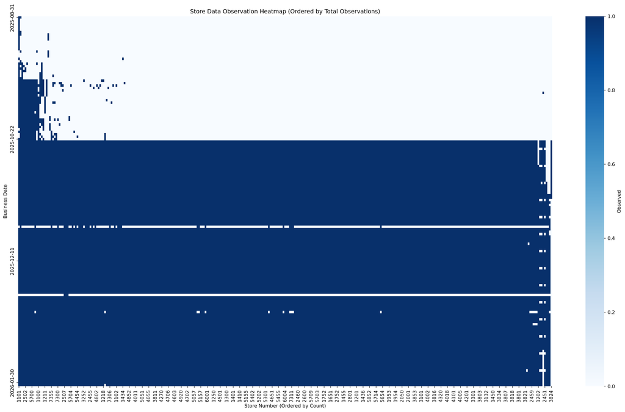

```python
# Create a pivot table to show presence of data for each store and date
store_sales_goals_zipline_df = store_sales_goals_zipline.to_pandas()
store_sales_goals_zipline_df["BUSINESS_DATE"] = pd.to_datetime(
    store_sales_goals_zipline_df["BUSINESS_DATE"]
).dt.date
pivot_data = store_sales_goals_zipline_df.pivot_table(
    index="BUSINESS_DATE",
    columns="STORE_NUMBER",
    values="FINANCE_TEAM_GOAL",
    aggfunc="count",
)

# Count observations per store and sort
store_counts = pivot_data.count().sort_values(ascending=False)
sorted_stores = store_counts.index

# Reorder columns by observation count
pivot_data = pivot_data[sorted_stores]

# Create binary heatmap (1 if observed, 0 if not)
heatmap_data = pivot_data.notna().astype(int)

# Create the heatmap
plt.figure(figsize=(20, 12))
sns.heatmap(heatmap_data, cmap="Blues", cbar_kws={"label": "Observed"}, yticklabels=50)
plt.title("Store Data Observation Heatmap (Ordered by Total Observations)")
plt.xlabel("Store Number (Ordered by Count)")
plt.ylabel("Business Date")
plt.tight_layout()
plt.show()
```

```python
# Filter to the start date
pre_filter_shape = store_sales_goals_zipline_df.shape
print(f"After filtering, the number of records is {store_sales_goals_zipline_df.shape}.")
store_sales_goals_zipline_df = store_sales_goals_zipline_df[
    store_sales_goals_zipline_df["BUSINESS_DATE"]
    >= pd.to_datetime(goal_start_date).date()
]
post_filter_shape = store_sales_goals_zipline_df.shape
change_in_records = pre_filter_shape[0] - post_filter_shape[0]
print(f"After filtering, the number of records is {store_sales_goals_zipline_df.shape}.")
print(f"Number of records removed: {change_in_records}")
```

```
After filtering, the number of records is (32854, 4).
After filtering, the number of records is (29454, 4).
Number of records removed: 3400
```

## Store Sales Goals Data over time

The store goals are similar to each other, small variations but generally quite consistent.

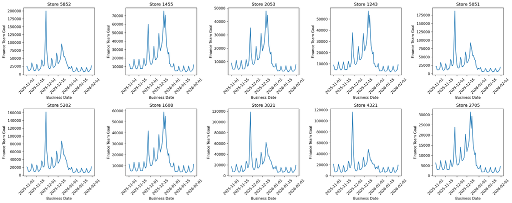

```python
# Select 10 random stores
random_stores = np.random.choice(
    store_sales_goals_zipline_df["STORE_NUMBER"].unique(), size=10, replace=False
)

# Create a 2x5 grid of subplots
fig, axes = plt.subplots(2, 5, figsize=(20, 8))
axes = axes.flatten()

# Plot each store in a separate subplot
for idx, store in enumerate(random_stores):
    store_data = store_sales_goals_zipline_df[
        store_sales_goals_zipline_df["STORE_NUMBER"] == store
    ]
    axes[idx].plot(store_data["BUSINESS_DATE"], store_data["FINANCE_TEAM_GOAL"])
    axes[idx].set_title(f"Store {store}")
    axes[idx].set_xlabel("Business Date")
    axes[idx].set_ylabel("Finance Team Goal")
    axes[idx].tick_params(axis="x", rotation=45)

plt.tight_layout()
plt.show()
```

### Stores with Missing Sales Goals Data

There are a few stores with missing sales goals data, which may require further investigation to determine the cause and potential impact on analysis.

```python
# Filter data after November 2025

# Get the total number of unique dates in the period
total_dates = store_sales_goals_zipline_df["BUSINESS_DATE"].nunique()

# Count observations per store after November 2025
store_obs_after_nov = store_sales_goals_zipline_df.groupby("STORE_NUMBER").size()
# Calculate missing days for each store
store_missing_days = total_dates - store_obs_after_nov

# Filter stores with more than 3 missing days
stores_with_missing = store_missing_days[store_missing_days > 3].sort_values(
    ascending=False
)

print(f"Total unique dates after November 2025: {total_dates}")
print(f"\nStores with more than 3 missing days after November 2025:\n")
print(stores_with_missing)
print(
    f"\nTotal number of stores with more than 3 missing days: {len(stores_with_missing)}"
)
```

```
Total unique dates after November 2025: 92

Stores with more than 3 missing days after November 2025:

STORE_NUMBER
3824    77
7301    20
1607    17
2451    15
2456    15
2454    15
3152    14
4605    10
1273     4
3551     4
6100     4
6101     4
dtype: int64

Total number of stores with more than 3 missing days: 12
```

```python
# associate_daily_sales_df = pd.read_csv('/home/sagemaker-user/smart-goals/raw-data/Associate_Daily_Sales_Data.csv', parse_dates=['Business_Date'], dtype={'Store_Num': str, 'Employee_Num': str})
# associate_daily_sales_df.columns = associate_daily_sales_df.columns.str.upper()
# associate_daily_sales_df = associate_daily_sales_df[['STORE_NUMBER', 'BUSINESS_DATE', 'EMPLOYEE_NUM', 'NET_SALES_AMOUNT']]
# associate_daily_sales_zipline = session.create_dataframe(associate_daily_sales_df)
associate_daily_sales_zipline = load_associate_daily_sales_snowpark(session)
```

```
INFO:smart_goals.utils.data_loaders:Renaming EMPLOYEE_NUM to SALES_ASSOCIATE
INFO:smart_goals.utils.data_loaders:Selecting columns: STORE_NUMBER, BUSINESS_DATE, SALES_ASSOCIATE, NET_SALES_AMOUNT
```

```python
store_daily_sales_agg_zipline = associate_daily_sales_zipline.group_by(
    ["BUSINESS_DATE", "STORE_NUMBER"]
).agg(F.sum("NET_SALES_AMOUNT").alias("NET_SALES_AMOUNT_ZIPLINE"))
# Cast TXN_DATE to date type, STORE_NBR to integer
store_daily_sales_agg_zipline = store_daily_sales_agg_zipline.with_column(
    "BUSINESS_DATE", F.to_date(store_daily_sales_agg_zipline["BUSINESS_DATE"])
).with_column(
    "STORE_NUMBER", store_daily_sales_agg_zipline["STORE_NUMBER"].cast("string")
)
```

## Store Sales Data

```python
coh_na_txn_tbl = session.table("prd_crm.dlab.dlab_coh_na_txn")

store_daily_sales_agg_dlabs = coh_na_txn_tbl.group_by("TXN_DATE", "STORE_NBR").agg(
    F.sum("USD_ITEM_NET_AMT").alias("NET_SALES_AMOUNT_DLABS")
)
# Cast TXN_DATE to date type, STORE_NBR to integer
store_daily_sales_agg_dlabs = (
    store_daily_sales_agg_dlabs.with_column(
        "BUSINESS_DATE", F.to_date(store_daily_sales_agg_dlabs["TXN_DATE"])
    )
    .with_column(
        "STORE_NUMBER", store_daily_sales_agg_dlabs["STORE_NBR"].cast("string")
    )
    .select("BUSINESS_DATE", "STORE_NUMBER", "NET_SALES_AMOUNT_DLABS")
)
```

```python
store_daily_sales_agg_all = store_daily_sales_agg_zipline.join(
    store_daily_sales_agg_dlabs,
    using_columns=["STORE_NUMBER", "BUSINESS_DATE"],
    how="inner",
)
```

```python
store_daily_sales_agg_all = store_daily_sales_agg_all.with_column(
    "SALES_AMOUNT_DIFF",
    F.round(
        store_daily_sales_agg_all["NET_SALES_AMOUNT_ZIPLINE"]
        - store_daily_sales_agg_all["NET_SALES_AMOUNT_DLABS"],
        2,
    ),
)
```

```python
# Plot the differences by dates
store_daily_sales_agg_all_df = store_daily_sales_agg_all.to_pandas()

# Show the stores with biggest differences
store_daily_sales_agg_all_df["ABS_SALES_AMOUNT_DIFF"] = store_daily_sales_agg_all_df["SALES_AMOUNT_DIFF"].abs()
top_diff_days = store_daily_sales_agg_all_df.groupby("BUSINESS_DATE").agg({
    "SALES_AMOUNT_DIFF": "sum",
    "ABS_SALES_AMOUNT_DIFF": "sum"
}).sort_values(by="ABS_SALES_AMOUNT_DIFF", ascending=False).head(10).reset_index()
print("Top 10 days with biggest sales amount differences between Zipline and DLABS:")
print(top_diff_days[["BUSINESS_DATE", "SALES_AMOUNT_DIFF", "ABS_SALES_AMOUNT_DIFF"]].to_string(index=False))
# Set output width to wide so we see all columns in the printout without wrapping
```

```
Top 10 days with biggest sales amount differences between Zipline and DLABS:
BUSINESS_DATE  SALES_AMOUNT_DIFF  ABS_SALES_AMOUNT_DIFF
   2025-09-27        -5248791.37             5248791.37
   2025-12-26         1179465.54             1672967.10
   2026-01-21        -1621245.54             1632655.98
   2025-11-28          -12545.51             1575114.93
   2025-12-23          -54106.31             1163943.47
   2025-12-20           66264.84             1152636.56
   2025-11-29           78691.19             1085964.99
   2025-12-22          -47435.09             1034182.79
   2025-12-27          593192.02             1020668.18
   2025-12-21          123995.43              987165.07
```

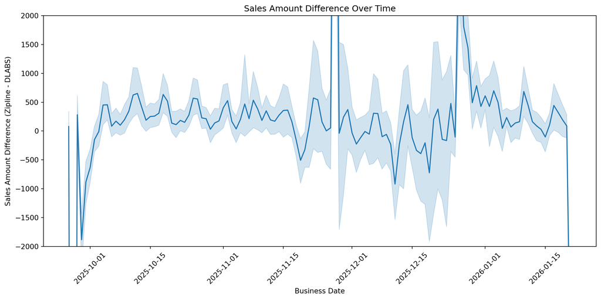

```python
plt.figure(figsize=(12, 6))
sns.lineplot(
    data=store_daily_sales_agg_all_df, x="BUSINESS_DATE", y="SALES_AMOUNT_DIFF"
)
plt.title("Sales Amount Difference Over Time")
plt.xlabel("Business Date")
plt.ylabel("Sales Amount Difference (Zipline - DLABS)")
plt.xticks(rotation=45)
plt.tight_layout()
plt.ylim(-2000, 2000)  # Zoom into y-axis range from -5000 to 5000
plt.show()
```

## Store Sales Goals vs Actuals

Broadly, we observe that actual sales aligns fairly well with the sales goals. This confirms that we can move ahead with the current sales goals and don’t need to explore corrections.

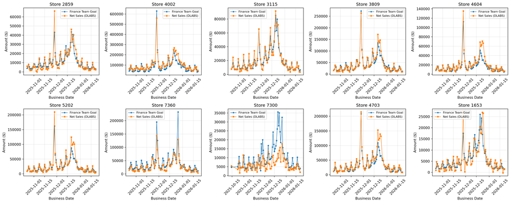

```python
# Select 10 random stores from the joined data
joined_data = store_daily_sales_agg_all.join(
    store_sales_goals_zipline,
    using_columns=["BUSINESS_DATE", "STORE_NUMBER"],
    how="inner",
)

# Get unique stores and sample 10
stores_with_data = joined_data.select("STORE_NUMBER").distinct().to_pandas()
random_stores_selected = np.random.choice(
    stores_with_data["STORE_NUMBER"].unique(), size=10, replace=False
)

# Convert to pandas for plotting
plot_data = joined_data.select(
    "BUSINESS_DATE", "STORE_NUMBER", "FINANCE_TEAM_GOAL", "NET_SALES_AMOUNT_DLABS"
).to_pandas()

# Create a 2x5 grid of subplots
fig, axes = plt.subplots(2, 5, figsize=(20, 8))
axes = axes.flatten()

# Plot each store in a separate subplot
for idx, store in enumerate(random_stores_selected):
    store_data = plot_data[plot_data["STORE_NUMBER"] == store].sort_values(
        "BUSINESS_DATE"
    )

    ax = axes[idx]
    ax.plot(
        store_data["BUSINESS_DATE"],
        store_data["FINANCE_TEAM_GOAL"],
        label="Finance Team Goal",
        marker="o",
        markersize=3,
        linewidth=1,
    )
    ax.plot(
        store_data["BUSINESS_DATE"],
        store_data["NET_SALES_AMOUNT_DLABS"],
        label="Net Sales (DLABS)",
        marker="s",
        markersize=3,
        linewidth=1,
    )

    ax.set_title(f"Store {store}")
    ax.set_xlabel("Business Date")
    ax.set_ylabel("Amount ($)")
    ax.tick_params(axis="x", rotation=45)
    ax.legend(loc="best", fontsize=8)
    ax.grid(True, alpha=0.3)

plt.tight_layout()
plt.show()
```

# 3. Aligning Store Sales to Hour of Day

## Calculate Sales by Hour of Day.

```python
store_daily_sales_hourly_dlabs = (
    coh_na_txn_tbl.filter(
        (F.nvl(F.col("STORE_NBR"), F.lit("-9999")) > F.lit("0"))
        & (F.col("STORE_NBR") != F.lit("ECOM"))
    )
    .with_column(
        "TXN_DATEHOUR", F.trunc(F.col("TXN_DATETIME").cast("timestamp"), F.lit("HOUR"))
    )
    .group_by("TXN_DATE", "TXN_DATEHOUR", "STORE_NBR")
    .agg(F.sum("USD_ITEM_NET_AMT").alias("NET_SALES_AMOUNT_DLABS"))
    .rename(
        {
            "TXN_DATE": "BUSINESS_DATE",
            "STORE_NBR": "STORE_NUMBER",
            "TXN_DATEHOUR": "BUSINESS_DATEHOUR",
        }
    )
)

store_daily_sales_hourly_dlabs.show(5)
```

```
-------------------------------------------------------------------------------------
|"BUSINESS_DATE"  |"BUSINESS_DATEHOUR"  |"STORE_NUMBER"  |"NET_SALES_AMOUNT_DLABS"  |
-------------------------------------------------------------------------------------
|2013-07-01       |2013-07-01 20:00:00  |2577            |778.90                    |
|2021-07-05       |2021-07-05 19:00:00  |3827            |35947.09                  |
|2017-06-14       |2017-06-14 14:00:00  |5152            |21466.48                  |
|2012-12-22       |2012-12-22 13:00:00  |3802            |35844.07                  |
|2012-11-23       |2012-11-23 13:00:00  |3811            |26519.35                  |
-------------------------------------------------------------------------------------
```

```python
store_hours_tbl_with_dups = load_store_hours_snowpark(session, deduplicate=False)
```

```
INFO:smart_goals.utils.data_loaders:Renaming columns: STORENUM->STORE_NUMBER, BUSINESSDATE->BUSINESS_DATE, OPENTIME->OPEN_TIME, CLOSETIME->CLOSE_TIME
```

```python
# Show duplicated rows in store_hours_tbl_with_dups
store_hours_tbl_with_dups_df = store_hours_tbl_with_dups.to_pandas()

# Find duplicates based on all columns
duplicated_mask = store_hours_tbl_with_dups_df.duplicated(keep=False)
duplicated_rows = store_hours_tbl_with_dups_df[duplicated_mask].sort_values(
    by=["STORE_NUMBER", "BUSINESS_DATE"]
)

print(f"Total number of duplicated rows: {len(duplicated_rows)}")
print(f"Number of unique duplicate sets: {len(duplicated_rows) - store_hours_tbl_with_dups_df.duplicated().sum()}")
print("\nDuplicated rows:")
duplicated_rows
```

```
Total number of duplicated rows: 81804
Number of unique duplicate sets: 40902

Duplicated rows:
```

|  | BRAND | STORE_NUMBER | BUSINESS_DATE | FMSID | OPEN_TIME | CLOSE_TIME | ISCLOSED | UPDATEDDATE | UPDATEDBY |
| --- | --- | --- | --- | --- | --- | --- | --- | --- | --- |
| 0 | CH | 1100 | 2025-09-26 | B056 | 2025-09-26 10:00:00 | 2025-09-26 21:00:00 | N | 2025-09-26 03:00:09.267 | Admin |
| 40902 | CH | 1100 | 2025-09-26 | B056 | 2025-09-26 10:00:00 | 2025-09-26 21:00:00 | N | 2025-09-26 03:00:09.267 | Admin |
| 1 | CH | 1100 | 2025-09-27 | B056 | 2025-09-27 10:00:00 | 2025-09-27 21:00:00 | N | 2025-09-27 03:00:13.280 | Admin |
| 40903 | CH | 1100 | 2025-09-27 | B056 | 2025-09-27 10:00:00 | 2025-09-27 21:00:00 | N | 2025-09-27 03:00:13.280 | Admin |
| 2 | CH | 1100 | 2025-09-28 | B056 | 2025-09-28 11:00:00 | 2025-09-28 18:00:00 | N | 2025-09-28 03:00:11.147 | Admin |
| ... | ... | ... | ... | ... | ... | ... | ... | ... | ... |
| 81801 | CH | 7504 | 2026-01-23 | F005 | 2026-01-23 11:00:00 | 2026-01-23 20:00:00 | N | 2026-01-21 03:00:19.660 | Admin |
| 40900 | CH | 7504 | 2026-01-24 | F005 | 2026-01-24 10:00:00 | 2026-01-24 19:00:00 | N | 2026-01-21 03:00:19.660 | Admin |
| 81802 | CH | 7504 | 2026-01-24 | F005 | 2026-01-24 10:00:00 | 2026-01-24 19:00:00 | N | 2026-01-21 03:00:19.660 | Admin |
| 40901 | CH | 7504 | 2026-01-25 | F005 | 2026-01-25 10:00:00 | 2026-01-25 19:00:00 | N | 2026-01-21 03:00:19.660 | Admin |
| 81803 | CH | 7504 | 2026-01-25 | F005 | 2026-01-25 10:00:00 | 2026-01-25 19:00:00 | N | 2026-01-21 03:00:19.660 | Admin |

81804 rows × 9 columns

Additionally, this file is corrupted, I modified the file manually to remove this errant field

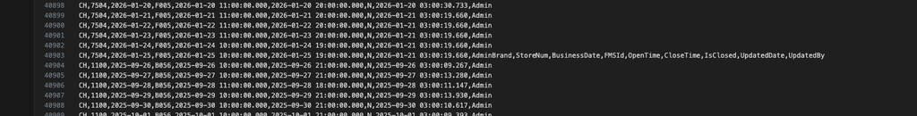

```python
pre_filter_shape = store_hours_tbl_with_dups_df.shape
print(f"Before deduplication, the number of records is {store_hours_tbl_with_dups_df.shape}.")
store_hours_tbl = load_store_hours_snowpark(session, deduplicate=True)
post_filter_shape = store_hours_tbl.count()
change_in_records = pre_filter_shape[0] - post_filter_shape
print(f"After deduplication, the number of records is {post_filter_shape}.")
print(f"Number of records removed: {change_in_records}")
```

```
INFO:smart_goals.utils.data_loaders:Renaming columns: STORENUM->STORE_NUMBER, BUSINESSDATE->BUSINESS_DATE, OPENTIME->OPEN_TIME, CLOSETIME->CLOSE_TIME
INFO:smart_goals.utils.data_loaders:Dropping duplicate rows based on STORE_NUMBER and BUSINESS_DATE
```

```
Before deduplication, the number of records is (81804, 9).
After deduplication, the number of records is 40902.
Number of records removed: 40902
```

```python
# Order the store_hours_tbl by business date and show the first 10 dates with sales differences
store_hours_tbl.order_by("BUSINESS_DATE").show(10)
```

```
-------------------------------------------------------------------------------------------------------------------------------------------------------------
|"BRAND"  |"STORE_NUMBER"  |"BUSINESS_DATE"      |"FMSID"  |"OPEN_TIME"          |"CLOSE_TIME"         |"ISCLOSED"  |"UPDATEDDATE"            |"UPDATEDBY"  |
-------------------------------------------------------------------------------------------------------------------------------------------------------------
|CH       |1100            |2025-09-26 00:00:00  |B056     |2025-09-26 10:00:00  |2025-09-26 21:00:00  |N           |2025-09-26 03:00:09.267  |Admin        |
|CH       |1130            |2025-09-26 00:00:00  |B064     |2025-09-26 10:00:00  |2025-09-26 19:00:00  |N           |2025-09-26 03:00:09.267  |Admin        |
|CH       |1104            |2025-09-26 00:00:00  |B060     |2025-09-26 10:00:00  |2025-09-26 21:00:00  |N           |2025-09-26 03:00:09.267  |Admin        |
|CH       |1205            |2025-09-26 00:00:00  |B074     |2025-09-26 10:00:00  |2025-09-26 21:00:00  |N           |2025-09-26 03:00:09.267  |Admin        |
|CH       |1201            |2025-09-26 00:00:00  |B070     |2025-09-26 10:00:00  |2025-09-26 20:00:00  |N           |2025-09-26 03:00:09.267  |Admin        |
|CH       |1105            |2025-09-26 00:00:00  |B061     |2025-09-26 10:00:00  |2025-09-26 21:00:00  |N           |2025-09-26 03:00:09.267  |Admin        |
|CH       |1102            |2025-09-26 00:00:00  |B058     |2025-09-26 10:00:00  |2025-09-26 20:00:00  |N           |2025-09-26 03:00:09.267  |Admin        |
|CH       |1206            |2025-09-26 00:00:00  |B075     |2025-09-26 10:00:00  |2025-09-26 21:00:00  |N           |2025-09-26 03:00:09.267  |Admin        |
|CH       |1202            |2025-09-26 00:00:00  |B071     |2025-09-26 00:00:00  |2025-09-26 00:00:00  |Y           |2025-09-26 03:00:09.267  |Admin        |
|CH       |1101            |2025-09-26 00:00:00  |B057     |2025-09-26 10:00:00  |2025-09-26 21:00:00  |N           |2025-09-26 03:00:09.267  |Admin        |
-------------------------------------------------------------------------------------------------------------------------------------------------------------
```

```python
store_hours_tbl = store_hours_tbl.select(
        "STORE_NUMBER",
        "BUSINESS_DATE",
        F.hour(F.col("OPEN_TIME").cast("timestamp")).alias("OPEN_HOUR"),
        F.hour(F.col("CLOSE_TIME").cast("timestamp")).alias("CLOSE_HOUR"),
    )
```

```python
# Show average open and close times by Store by Week
store_hours_weekly = (
    store_hours_tbl.with_column(
        "WEEK_START_DATE",
        F.date_trunc("Week", store_hours_tbl["BUSINESS_DATE"]),
    )
    .group_by("STORE_NUMBER", "WEEK_START_DATE")
    .agg(
        F.avg(F.col("OPEN_HOUR")).alias("AVG_OPEN_TIME"),
        F.avg(F.col("CLOSE_HOUR")).alias("AVG_CLOSE_TIME"),
    )
    .order_by("STORE_NUMBER", "WEEK_START_DATE")
)

# Plot the average open and close times by store over time
store_hours_weekly_df = store_hours_weekly.to_pandas()
```

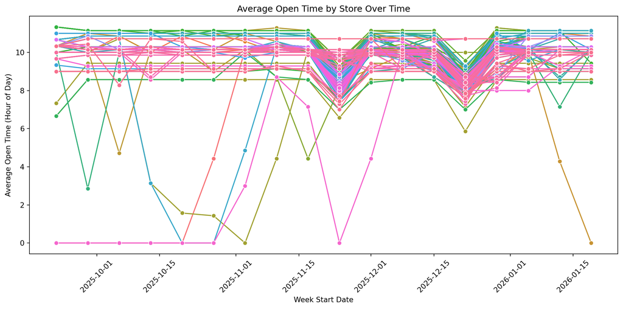

```python
plt.figure(figsize=(12, 6))
sns.lineplot(
    data=store_hours_weekly_df,
    x="WEEK_START_DATE",
    y="AVG_OPEN_TIME",
    hue="STORE_NUMBER",
    marker="o",
    legend=False
)
plt.title("Average Open Time by Store Over Time")
plt.xlabel("Week Start Date")
plt.ylabel("Average Open Time (Hour of Day)")
plt.xticks(rotation=45)
plt.tight_layout()
plt.show()
```

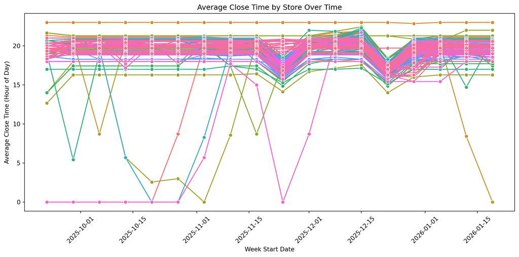

```python
plt.figure(figsize=(12, 6))
sns.lineplot(
    data=store_hours_weekly_df,
    x="WEEK_START_DATE",
    y="AVG_CLOSE_TIME",
    hue="STORE_NUMBER",
    marker="o",
    legend=False
)
plt.title("Average Close Time by Store Over Time")
plt.xlabel("Week Start Date")
plt.ylabel("Average Close Time (Hour of Day)")
plt.xticks(rotation=45)
plt.tight_layout()
plt.show()
```

To generate a cleaned up version of this data, I take the most common opening and closing time. This will need to be corrected.

```python
store_hours_simplified = (
    store_hours_tbl
    .group_by(F.col("STORE_NUMBER"))
    .agg(
        F.mode("OPEN_HOUR").alias("OPEN_HOUR"), F.mode("CLOSE_HOUR").alias("CLOSE_HOUR")
    )
)
```

There are still stores with an opening or closing time of 0, for these we just fill in a guess.

```python
# Find stores with 0 as the open or close time
# store_hours_simplified.filter((store_hours_simplified'OPEN_HOUR'] == F.lit(0)) | (store_hours_simplified['CLOSE_HOUR'] == F.lit(0))).show()
store_hours_simplified.filter(
    (store_hours_simplified["OPEN_HOUR"] == 0)
    | (store_hours_simplified["CLOSE_HOUR"] == 0)
).show()
```

```
-----------------------------------------------
|"STORE_NUMBER"  |"OPEN_HOUR"  |"CLOSE_HOUR"  |
-----------------------------------------------
|1202            |10           |0             |
|7301            |0            |0             |
-----------------------------------------------
```

```python
# IF a store in the store_hours_simplied has 0 as open or close hours, replace it with the global average
store_hours_simplified = store_hours_simplified.with_column(
    "OPEN_HOUR",
    F.when(store_hours_simplified["OPEN_HOUR"] == 0, 10).otherwise(
        store_hours_simplified["OPEN_HOUR"]
    ),
).with_column(
    "CLOSE_HOUR",
    F.when(store_hours_simplified["CLOSE_HOUR"] == 0, 20).otherwise(
        store_hours_simplified["CLOSE_HOUR"]
    ),
)
```

```python
store_daily_sales_hourly_adjusted = store_daily_sales_hourly_dlabs.join(
    store_hours_tbl, using_columns=["STORE_NUMBER", "BUSINESS_DATE"], how="inner"
).order_by(["STORE_NUMBER", "BUSINESS_DATE"])
```

I don’t think I need to join at this granularity, I think I can do the percentages and then join to the final dataset

```python
store_daily_sales_hourly_adjusted.show()
```

```
------------------------------------------------------------------------------------------------------------------
|"STORE_NUMBER"  |"BUSINESS_DATE"  |"BUSINESS_DATEHOUR"  |"NET_SALES_AMOUNT_DLABS"  |"OPEN_HOUR"  |"CLOSE_HOUR"  |
------------------------------------------------------------------------------------------------------------------
|1100            |2025-09-26       |2025-09-26 12:00:00  |625.50                    |10           |21            |
|1100            |2025-09-26       |2025-09-26 16:00:00  |1730.50                   |10           |21            |
|1100            |2025-09-26       |2025-09-26 18:00:00  |1151.50                   |10           |21            |
|1100            |2025-09-26       |2025-09-26 14:00:00  |1582.00                   |10           |21            |
|1100            |2025-09-26       |2025-09-26 19:00:00  |790.00                    |10           |21            |
|1100            |2025-09-26       |2025-09-26 17:00:00  |640.00                    |10           |21            |
|1100            |2025-09-26       |2025-09-26 10:00:00  |95.00                     |10           |21            |
|1100            |2025-09-26       |2025-09-26 15:00:00  |1075.50                   |10           |21            |
|1100            |2025-09-26       |2025-09-26 11:00:00  |830.00                    |10           |21            |
|1100            |2025-09-26       |2025-09-26 13:00:00  |1585.00                   |10           |21            |
------------------------------------------------------------------------------------------------------------------
```

Start from all data and join just the simplified store hours

```python
# Calculate the Percent of Sales / Day for each store for each day
from snowflake.snowpark.window import Window

window_spec = Window.partition_by("STORE_NUMBER", "BUSINESS_DATE")
store_daily_sales_hourly_adjusted = store_daily_sales_hourly_dlabs.filter(
    F.col("BUSINESS_DATE") > F.lit(analysis_start_date)
)

# If we get Store Daily hours, this will need to join on BUSINESS_DATE as well.
store_daily_sales_hourly_adjusted = store_daily_sales_hourly_adjusted.join(
    store_hours_simplified, using_columns=["STORE_NUMBER"], how="inner"
)

# Calculate the Hourly Percent of Daily Sales for each store for each Hour
store_daily_sales_hourly_adjusted = store_daily_sales_hourly_adjusted.with_column(
    "PCT_DAILY_SALES",
    F.col("NET_SALES_AMOUNT_DLABS")
    / F.nullifzero(F.sum("NET_SALES_AMOUNT_DLABS").over(window_spec)),
).order_by(["STORE_NUMBER", "BUSINESS_DATE", "BUSINESS_DATEHOUR"])

store_daily_sales_hourly_adjusted.show()
```

```
--------------------------------------------------------------------------------------------------------------------------------------
|"STORE_NUMBER"  |"BUSINESS_DATE"  |"BUSINESS_DATEHOUR"  |"NET_SALES_AMOUNT_DLABS"  |"OPEN_HOUR"  |"CLOSE_HOUR"  |"PCT_DAILY_SALES"  |
--------------------------------------------------------------------------------------------------------------------------------------
|1100            |2023-01-02       |2023-01-02 10:00:00  |485.00                    |10           |21            |0.08403725         |
|1100            |2023-01-02       |2023-01-02 11:00:00  |74.25                     |10           |21            |0.01286550         |
|1100            |2023-01-02       |2023-01-02 12:00:00  |-637.50                   |10           |21            |-0.11046134        |
|1100            |2023-01-02       |2023-01-02 13:00:00  |502.50                    |10           |21            |0.08706953         |
|1100            |2023-01-02       |2023-01-02 14:00:00  |980.00                    |10           |21            |0.16980723         |
|1100            |2023-01-02       |2023-01-02 15:00:00  |1184.00                   |10           |21            |0.20515486         |
|1100            |2023-01-02       |2023-01-02 16:00:00  |1251.00                   |10           |21            |0.21676413         |
|1100            |2023-01-02       |2023-01-02 17:00:00  |1117.00                   |10           |21            |0.19354559         |
|1100            |2023-01-02       |2023-01-02 18:00:00  |420.00                    |10           |21            |0.07277453         |
|1100            |2023-01-02       |2023-01-02 20:00:00  |395.00                    |10           |21            |0.06844271         |
--------------------------------------------------------------------------------------------------------------------------------------
```

# Hourly Sales Algorithm

This is the core algorithm, we convert the Hour of sales to a Hours Since Open, if sales happened before the store was opened or after it closed, we shift that sale into the first or last hour of the day.

We apply a correction for sales that happen before the store opens or after it closes, we shift those sales into the first or last hour of the day respectively using the following logic:

- If `HOURS_SINCE_OPEN` is less than or equal to 1 (meaning sales occurred before or at the first hour of opening), set it to 1 (the first hour)
- If `HOURS_SINCE_OPEN` is greater than or equal to the total operating hours (meaning sales occurred after closing), set it to the last hour of operation
- Otherwise, keep the original `HOURS_SINCE_OPEN` value unchanged

This ensures all sales are mapped to valid operating hours, with pre-opening sales shifted to hour 1 and post-closing sales shifted to the final hour.

```python
store_meta = load_store_data(session)
```

```
INFO:smart_goals.utils.data_loaders:Renaming columns: EMP_ID->SALES_ASSOCIATE, MST_LOCATION_CODE->STORE_NUMBER, CAL_DATE->BUSINESS_DATE
INFO:smart_goals.utils.data_loaders:Selecting columns: STORE_NUMBER, CHNL_DESC, REGION_DESC, DISTRICT_DESC
INFO:smart_goals.utils.data_loaders:Dropping duplicate rows based on STORE_NUMBER
```

```python
store_meta.show()
```

```
---------------------------------------------------------------------------------------------------
|"STORE_NUMBER"  |"CHNL_DESC"           |"REGION_DESC"   |"DISTRICT_DESC"                         |
---------------------------------------------------------------------------------------------------
|1211            |Coach Retail          |West Region     |Northern California / NW (NWilley)      |
|1436            |Coach Retail          |South Region    |Florida / Puerto Rico (IGomez)          |
|4009            |Coach Factory Stores  |FS South        |FS South Florida/Puerto Rico (CCarleo)  |
|3101            |Coach Retail          |Central Region  |Texas South (BTamez)                    |
|3551            |Coach Retail          |South Region    |Florida / Puerto Rico (IGomez)          |
|2052            |Coach Retail          |Central Region  |Detroit / Ohio (CDiMarco)               |
|1276            |Coach Retail          |West Region     |Southern California (TSchultz)          |
|4900            |Coach Factory Stores  |FS Central      |FS Midwest (AVerbout)                   |
|3112            |Coach Retail          |Central Region  |Texas South (BTamez)                    |
|7327            |Coach Retail          |Canada Region   |Eastern Canada (KKelly)                 |
---------------------------------------------------------------------------------------------------
```

```python
# Check for duplicates in store_meta by STORE_NUMBER
store_meta_df = store_meta.to_pandas()

# Check if there are any duplicate STORE_NUMBERs
duplicate_stores = store_meta_df[store_meta_df.duplicated(subset=['STORE_NUMBER'], keep=False)]

if len(duplicate_stores) > 0:
    print(f"Found {len(duplicate_stores)} duplicate STORE_NUMBER entries")
    print("\nDuplicate stores:")
    print(duplicate_stores.sort_values('STORE_NUMBER'))

    # Show count of duplicates per store
    duplicate_counts = duplicate_stores.groupby('STORE_NUMBER').size().sort_values(ascending=False)
    print(f"\nNumber of duplicates per STORE_NUMBER:")
    print(duplicate_counts)
else:
    print("No duplicate STORE_NUMBERs found in store_meta")

# Show total number of unique stores
print(f"\nTotal rows in store_meta: {len(store_meta_df)}")
print(f"Unique STORE_NUMBERs: {store_meta_df['STORE_NUMBER'].nunique()}")
```

```
No duplicate STORE_NUMBERs found in store_meta

Total rows in store_meta: 328
Unique STORE_NUMBERs: 328
```

```python
store_hourly_pct = (
    store_daily_sales_hourly_adjusted.with_column("HOUR", F.hour("BUSINESS_DATEHOUR"))
    .with_column("MONTH", F.month("BUSINESS_DATE"))
    .with_column("DAY_OF_WEEK", F.dayofweek("BUSINESS_DATE"))
    .with_column("WEEK_OF_YEAR", F.weekofyear("BUSINESS_DATE"))
    .with_column("HOURS_SINCE_OPEN", F.col("HOUR") - F.col("OPEN_HOUR") + 1)
    .with_column(
        "HOURS_SINCE_OPEN_CORRECTED",
        F.when(F.col("HOURS_SINCE_OPEN") <= 1, 1)
        .when(
            F.col("HOURS_SINCE_OPEN") >= (F.col("CLOSE_HOUR") - F.col("OPEN_HOUR")),
            F.col("CLOSE_HOUR") - F.col("OPEN_HOUR"),
        )
        .otherwise(F.col("HOURS_SINCE_OPEN")),
    )
    .with_column(
        "WAS_CORRECTED",
        F.when(F.col("HOURS_SINCE_OPEN") != F.col("HOURS_SINCE_OPEN_CORRECTED"), True)
        .otherwise(False),
    )
)
```

```python
store_hourly_pct = store_hourly_pct.join(store_meta.select('STORE_NUMBER', 'CHNL_DESC'), using_columns = 'STORE_NUMBER')
```

```python
# Show which records were corrected and analyze the pattern
corrected_records = store_hourly_pct.filter(F.col("WAS_CORRECTED") == True)

print(f"Total corrected records: {corrected_records.count()}")
print(f"Percentage of records corrected: {corrected_records.count() / store_hourly_pct.count() * 100:.2f}%")

# Show sample of corrected records
print("\nSample of corrected records:")
corrected_records.select(
    "STORE_NUMBER",
    "BUSINESS_DATE",
    "BUSINESS_DATEHOUR",
    "HOUR",
    "OPEN_HOUR",
    "CLOSE_HOUR",
    "HOURS_SINCE_OPEN",
    "HOURS_SINCE_OPEN_CORRECTED",
    "NET_SALES_AMOUNT_DLABS",
    "PCT_DAILY_SALES"
).show(20)

# Analyze correction patterns
print("\nCorrected to first hour (pre-opening sales):")
corrected_to_first = corrected_records.filter(F.col("HOURS_SINCE_OPEN_CORRECTED") == 1)
print(f"Count: {corrected_to_first.count()}")

print("\nCorrected to last hour (post-closing sales):")
corrected_to_last = corrected_records.filter(
    F.col("HOURS_SINCE_OPEN_CORRECTED") == (F.col("CLOSE_HOUR") - F.col("OPEN_HOUR"))
)
print(f"Count: {corrected_to_last.count()}")

# Show distribution of hours that needed correction
print("\nDistribution of original hours for corrected records:")
corrected_records.group_by("HOUR").agg(
    F.count("*").alias("COUNT")
).order_by("HOUR").show()
```

```
Total corrected records: 157538
Percentage of records corrected: 4.81%

Sample of corrected records:
---------------------------------------------------------------------------------------------------------------------------------------------------------------------------------------------------
|"STORE_NUMBER"  |"BUSINESS_DATE"  |"BUSINESS_DATEHOUR"  |"HOUR"  |"OPEN_HOUR"  |"CLOSE_HOUR"  |"HOURS_SINCE_OPEN"  |"HOURS_SINCE_OPEN_CORRECTED"  |"NET_SALES_AMOUNT_DLABS"  |"PCT_DAILY_SALES"  |
---------------------------------------------------------------------------------------------------------------------------------------------------------------------------------------------------
|1100            |2023-01-21       |2023-01-21 09:00:00  |9       |10           |21            |0                   |1                             |-125.00                   |-0.03099045        |
|1100            |2023-02-03       |2023-02-03 21:00:00  |21      |10           |21            |12                  |11                            |75.00                     |0.01412695         |
|1100            |2023-02-10       |2023-02-10 08:00:00  |8       |10           |21            |-1                  |1                             |125.00                    |0.01063603         |
|1100            |2023-02-11       |2023-02-11 21:00:00  |21      |10           |21            |12                  |11                            |75.00                     |0.00689402         |
|1100            |2023-02-14       |2023-02-14 08:00:00  |8       |10           |21            |-1                  |1                             |0.00                      |0E-8               |
|1100            |2023-02-14       |2023-02-14 21:00:00  |21      |10           |21            |12                  |11                            |265.50                    |0.01968197         |
|1100            |2023-03-07       |2023-03-07 22:00:00  |22      |10           |21            |13                  |11                            |0.00                      |0E-8               |
|1100            |2023-03-21       |2023-03-21 21:00:00  |21      |10           |21            |12                  |11                            |195.00                    |0.02907627         |
|1100            |2023-03-31       |2023-03-31 09:00:00  |9       |10           |21            |0                   |1                             |642.25                    |0.07720093         |
|1100            |2023-04-13       |2023-04-13 09:00:00  |9       |10           |21            |0                   |1                             |-312.26                   |-0.03275968        |
|1100            |2023-04-14       |2023-04-14 21:00:00  |21      |10           |21            |12                  |11                            |420.00                    |0.07358739         |
|1100            |2023-04-15       |2023-04-15 21:00:00  |21      |10           |21            |12                  |11                            |625.00                    |0.04517202         |
|1100            |2023-04-28       |2023-04-28 01:00:00  |1       |10           |21            |-8                  |1                             |-30.00                    |-0.00369458        |
|1100            |2023-05-01       |2023-05-01 00:00:00  |0       |10           |21            |-9                  |1                             |-95.00                    |-0.01075391        |
|1100            |2023-05-02       |2023-05-02 23:00:00  |23      |10           |21            |14                  |11                            |41.30                     |0.00521363         |
|1100            |2023-05-03       |2023-05-03 21:00:00  |21      |10           |21            |12                  |11                            |675.00                    |0.10229799         |
|1100            |2023-05-06       |2023-05-06 03:00:00  |3       |10           |21            |-6                  |1                             |-495.00                   |-0.03319307        |
|1100            |2023-05-09       |2023-05-09 02:00:00  |2       |10           |21            |-7                  |1                             |-221.25                   |-0.01595198        |
|1100            |2023-05-10       |2023-05-10 03:00:00  |3       |10           |21            |-6                  |1                             |-71.25                    |-0.00884269        |
|1100            |2023-05-13       |2023-05-13 09:00:00  |9       |10           |21            |0                   |1                             |225.00                    |0.01001302         |
---------------------------------------------------------------------------------------------------------------------------------------------------------------------------------------------------


Corrected to first hour (pre-opening sales):
Count: 26014

Corrected to last hour (post-closing sales):
Count: 131144

Distribution of original hours for corrected records:
--------------------
|"HOUR"  |"COUNT"  |
--------------------
|0       |1190     |
|1       |1212     |
|2       |793      |
|3       |705      |
|4       |382      |
|5       |294      |
|6       |760      |
|7       |1189     |
|8       |3782     |
|9       |10787    |
--------------------
```

```python
# Extract hour and create visualizations for seasonal patterns
import matplotlib.pyplot as plt
import seaborn as sns
from snowflake.snowpark import functions as F

# Convert to pandas for visualization
hourly_pct_pd = store_hourly_pct.select(
    "BUSINESS_DATE",
    "HOUR",
    "MONTH",
    "DAY_OF_WEEK",
    "WEEK_OF_YEAR",
    "STORE_NUMBER",
    "PCT_DAILY_SALES",
    "NET_SALES_AMOUNT_DLABS",
    "HOURS_SINCE_OPEN_CORRECTED",
    "CHNL_DESC"
).to_pandas()
```

```python
# Check for duplicates in hourly_pct_pd by STORE_NUMBER, BUSINESS_DATE, HOUR
duplicate_mask = hourly_pct_pd.duplicated(subset=['STORE_NUMBER', 'BUSINESS_DATE', 'HOUR'], keep=False)
duplicate_records = hourly_pct_pd[duplicate_mask].sort_values(by=['STORE_NUMBER', 'BUSINESS_DATE', 'HOUR'])

print(f"Total number of duplicate records: {len(duplicate_records)}")
print(f"Percentage of duplicates: {len(duplicate_records) / len(hourly_pct_pd) * 100:.2f}%")

if len(duplicate_records) > 0:
    print(f"\nNumber of unique duplicate sets: {duplicate_records.groupby(['STORE_NUMBER', 'BUSINESS_DATE', 'HOUR']).ngroups}")
    print("\nSample of duplicate records:")
    print(duplicate_records[['STORE_NUMBER', 'BUSINESS_DATE', 'HOUR', 'PCT_DAILY_SALES', 'NET_SALES_AMOUNT_DLABS', 'HOURS_SINCE_OPEN_CORRECTED']].head(20))

    # Show how many duplicates per combination
    dup_counts = duplicate_records.groupby(['STORE_NUMBER', 'BUSINESS_DATE', 'HOUR']).size()
    print("\nDistribution of duplicate counts:")
    print(dup_counts.value_counts().sort_index())
else:
    print("\nNo duplicates found in hourly_pct_pd by STORE_NUMBER, BUSINESS_DATE, HOUR")
```

```
Total number of duplicate records: 0
Percentage of duplicates: 0.00%

No duplicates found in hourly_pct_pd by STORE_NUMBER, BUSINESS_DATE, HOUR
```

```python
hourly_pct_pd
```

|  | BUSINESS_DATE | HOUR | MONTH | DAY_OF_WEEK | WEEK_OF_YEAR | STORE_NUMBER | PCT_DAILY_SALES | NET_SALES_AMOUNT_DLABS | HOURS_SINCE_OPEN_CORRECTED | CHNL_DESC |
| --- | --- | --- | --- | --- | --- | --- | --- | --- | --- | --- |
| 0 | 2023-01-02 | 10 | 1 | 1 | 1 | 1100 | 0.084037 | 485.00 | 1 | Coach Retail |
| 1 | 2023-01-02 | 11 | 1 | 1 | 1 | 1100 | 0.012866 | 74.25 | 2 | Coach Retail |
| 2 | 2023-01-02 | 12 | 1 | 1 | 1 | 1100 | -0.110461 | -637.50 | 3 | Coach Retail |
| 3 | 2023-01-02 | 13 | 1 | 1 | 1 | 1100 | 0.087070 | 502.50 | 4 | Coach Retail |
| 4 | 2023-01-02 | 14 | 1 | 1 | 1 | 1100 | 0.169807 | 980.00 | 5 | Coach Retail |
| ... | ... | ... | ... | ... | ... | ... | ... | ... | ... | ... |
| 3273900 | 2026-02-17 | 18 | 2 | 2 | 8 | 7364 | 0.094963 | 687.49 | 9 | Coach Factory Stores |
| 3273901 | 2026-02-17 | 19 | 2 | 2 | 8 | 7364 | 0.124193 | 899.10 | 10 | Coach Factory Stores |
| 3273902 | 2026-02-17 | 20 | 2 | 2 | 8 | 7364 | 0.060174 | 435.63 | 11 | Coach Factory Stores |
| 3273903 | 2026-02-17 | 21 | 2 | 2 | 8 | 7364 | 0.010875 | 78.73 | 11 | Coach Factory Stores |
| 3273904 | 2026-02-17 | 23 | 2 | 2 | 8 | 7364 | -0.007955 | -57.59 | 11 | Coach Factory Stores |

3273905 rows × 10 columns

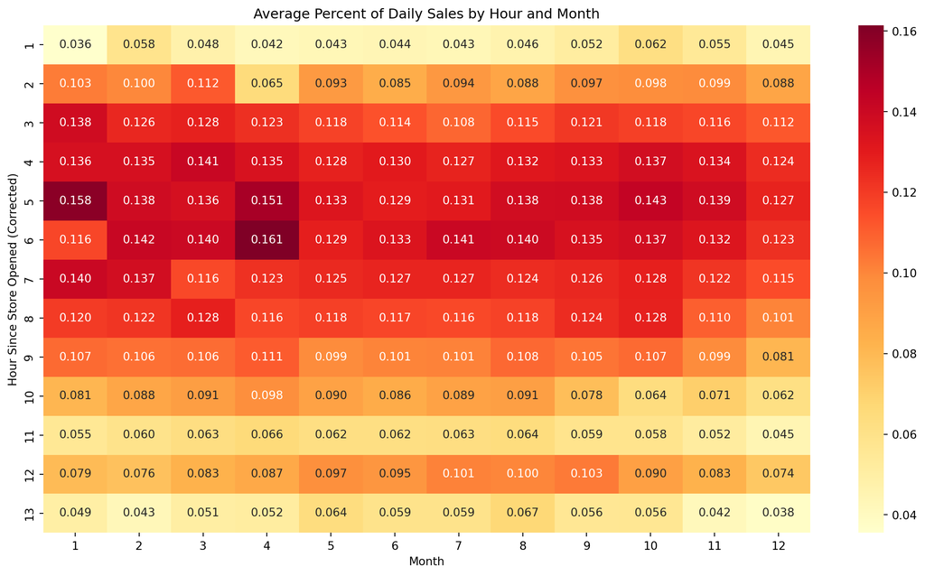

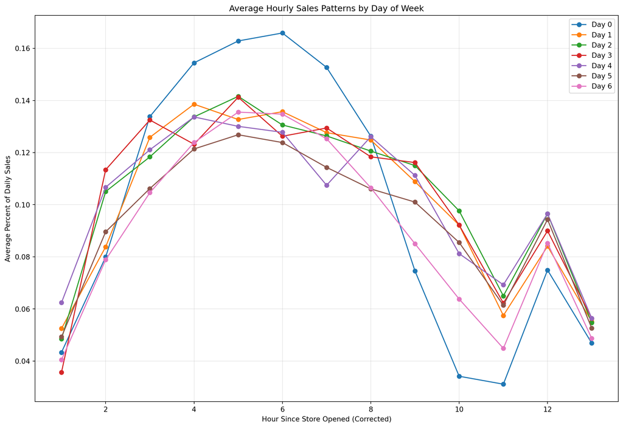

```
INFO:matplotlib.category:Using categorical units to plot a list of strings that are all parsable as floats or dates. If these strings should be plotted as numbers, cast to the appropriate data type before plotting.
INFO:matplotlib.category:Using categorical units to plot a list of strings that are all parsable as floats or dates. If these strings should be plotted as numbers, cast to the appropriate data type before plotting.
```

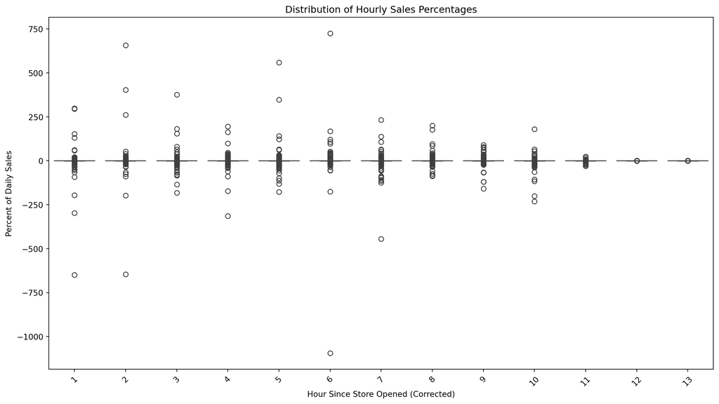

```python
# 1. Heatmap: Average percent sales by hour and month
plt.figure(figsize=(15, 8))
heatmap_data = hourly_pct_pd.pivot_table(
    values="PCT_DAILY_SALES",
    index="HOURS_SINCE_OPEN_CORRECTED",
    columns="MONTH",
    aggfunc="mean",
)
sns.heatmap(heatmap_data, annot=True, fmt=".3f", cmap="YlOrRd")
plt.title("Average Percent of Daily Sales by Hour and Month")
plt.xlabel("Month")
plt.ylabel("Hour Since Store Opened (Corrected)")
plt.show()

# 2. Line plot: Average hourly patterns by day of week
plt.figure(figsize=(15, 10))
for dow in sorted(hourly_pct_pd["DAY_OF_WEEK"].unique()):
    dow_data = hourly_pct_pd[hourly_pct_pd["DAY_OF_WEEK"] == dow]
    hourly_avg = dow_data.groupby("HOURS_SINCE_OPEN_CORRECTED")[
        "PCT_DAILY_SALES"
    ].mean()
    plt.plot(hourly_avg.index, hourly_avg.values, marker="o", label=f"Day {dow}")

plt.title("Average Hourly Sales Patterns by Day of Week")
plt.xlabel("Hour Since Store Opened (Corrected)")
plt.ylabel("Average Percent of Daily Sales")
plt.legend()
plt.grid(True, alpha=0.3)
plt.show()

# 3. Box plot: Distribution of hourly percentages
plt.figure(figsize=(15, 8))
sns.boxplot(data=hourly_pct_pd, x="HOURS_SINCE_OPEN_CORRECTED", y="PCT_DAILY_SALES")
plt.title("Distribution of Hourly Sales Percentages")
plt.xlabel("Hour Since Store Opened (Corrected)")
plt.ylabel("Percent of Daily Sales")
plt.xticks(rotation=45)
plt.show()
```

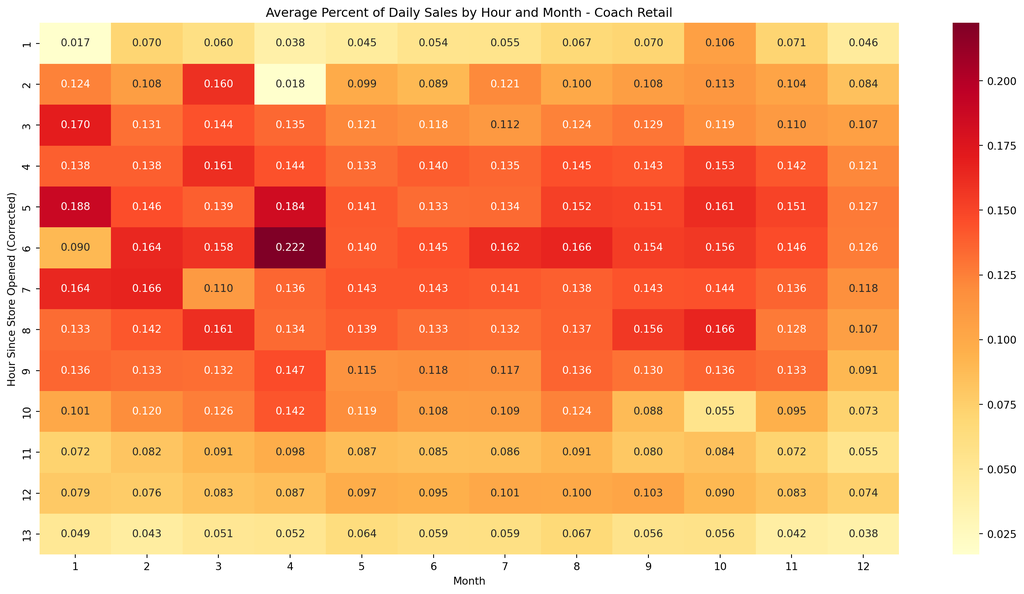

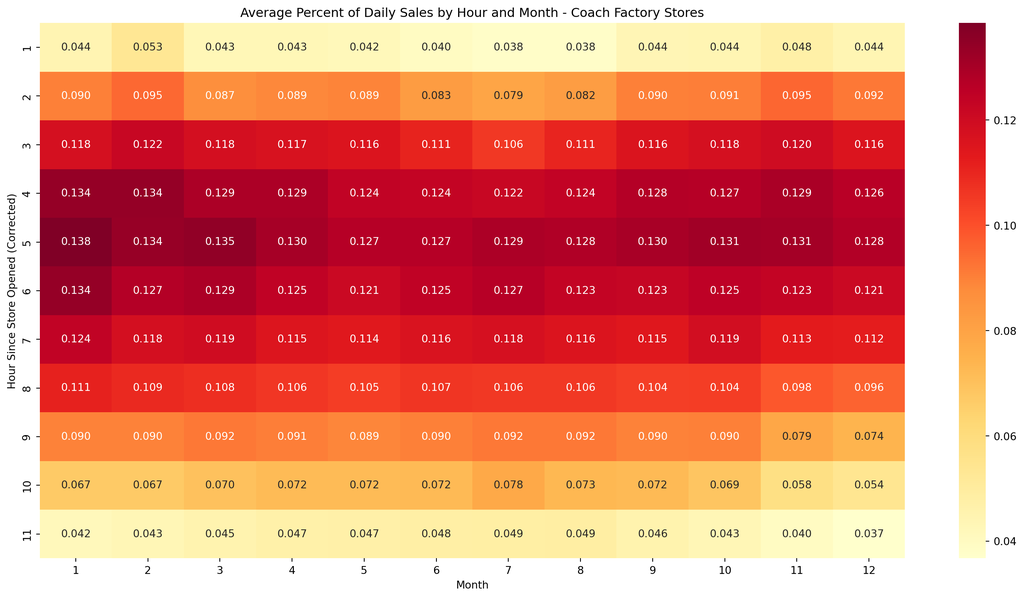

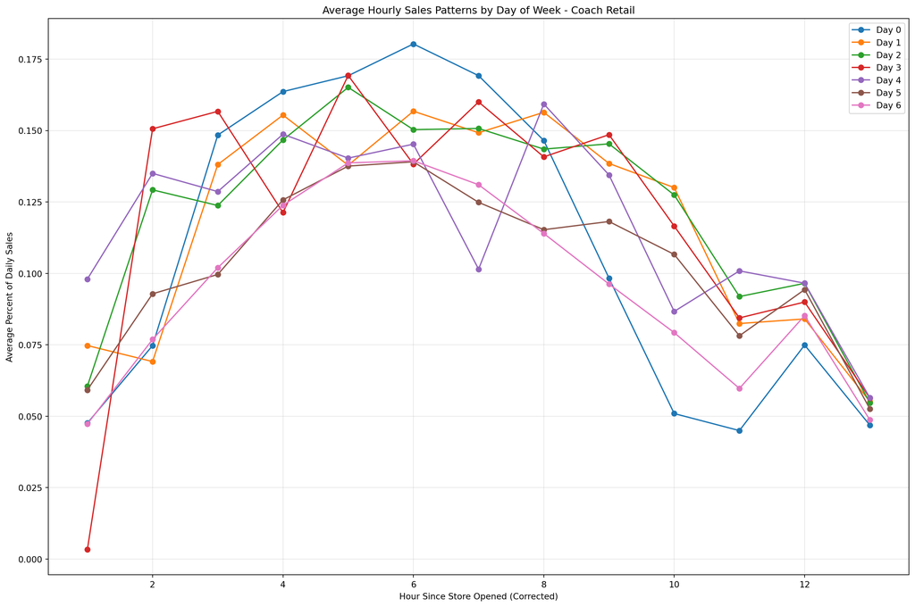

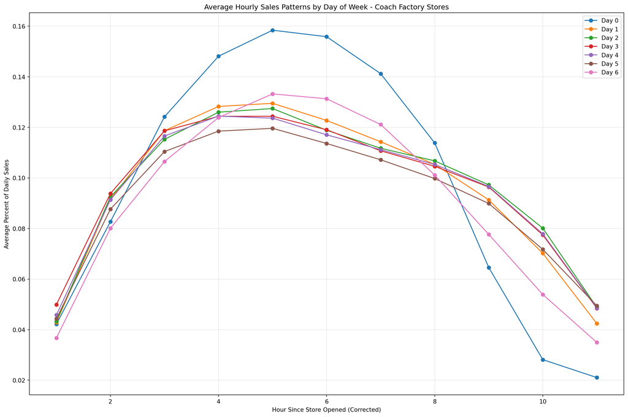

```
INFO:matplotlib.category:Using categorical units to plot a list of strings that are all parsable as floats or dates. If these strings should be plotted as numbers, cast to the appropriate data type before plotting.
INFO:matplotlib.category:Using categorical units to plot a list of strings that are all parsable as floats or dates. If these strings should be plotted as numbers, cast to the appropriate data type before plotting.
```

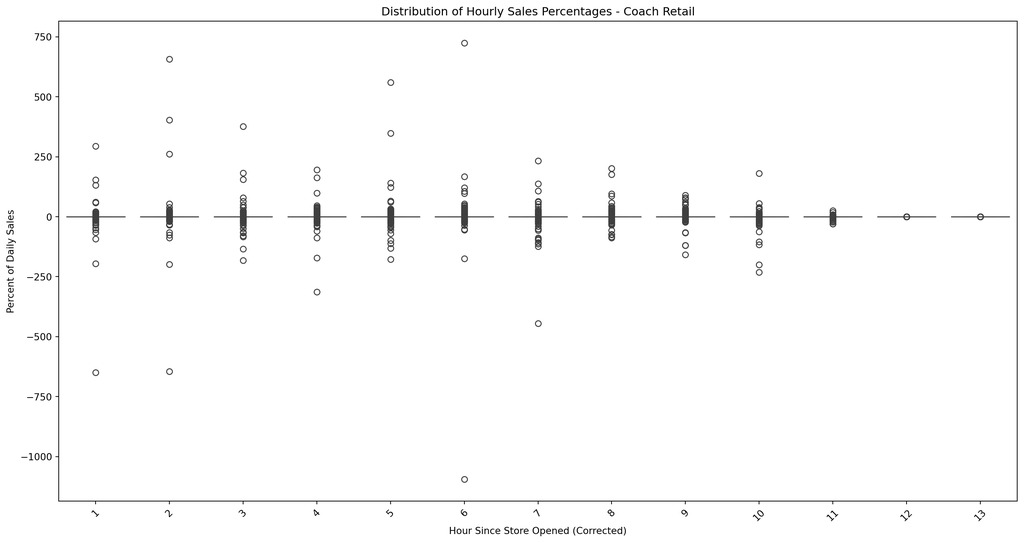

```
INFO:matplotlib.category:Using categorical units to plot a list of strings that are all parsable as floats or dates. If these strings should be plotted as numbers, cast to the appropriate data type before plotting.
INFO:matplotlib.category:Using categorical units to plot a list of strings that are all parsable as floats or dates. If these strings should be plotted as numbers, cast to the appropriate data type before plotting.
```

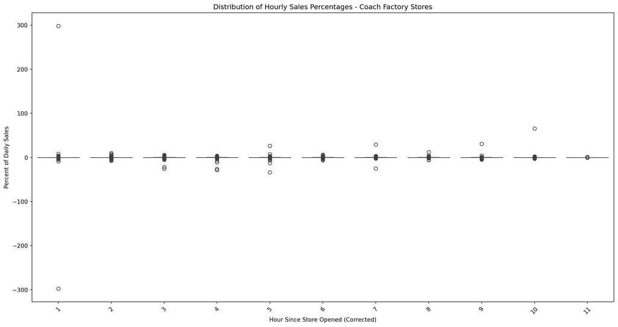

```python
# Split analysis by CHNL_DESC

# Get unique channel descriptions
channels = hourly_pct_pd["CHNL_DESC"].unique()

# 1. Heatmap: Average percent sales by hour and month for each channel
for channel in channels:
    channel_data = hourly_pct_pd[hourly_pct_pd["CHNL_DESC"] == channel]

    plt.figure(figsize=(15, 8))
    heatmap_data = channel_data.pivot_table(
        values="PCT_DAILY_SALES",
        index="HOURS_SINCE_OPEN_CORRECTED",
        columns="MONTH",
        aggfunc="mean",
    )
    sns.heatmap(heatmap_data, annot=True, fmt=".3f", cmap="YlOrRd")
    plt.title(f"Average Percent of Daily Sales by Hour and Month - {channel}")
    plt.xlabel("Month")
    plt.ylabel("Hour Since Store Opened (Corrected)")
    plt.tight_layout()
    plt.show()

# 2. Line plot: Average hourly patterns by day of week for each channel
for channel in channels:
    channel_data = hourly_pct_pd[hourly_pct_pd["CHNL_DESC"] == channel]

    plt.figure(figsize=(15, 10))
    for dow in sorted(channel_data["DAY_OF_WEEK"].unique()):
        dow_data = channel_data[channel_data["DAY_OF_WEEK"] == dow]
        hourly_avg = dow_data.groupby("HOURS_SINCE_OPEN_CORRECTED")["PCT_DAILY_SALES"].mean()
        plt.plot(hourly_avg.index, hourly_avg.values, marker="o", label=f"Day {dow}")

    plt.title(f"Average Hourly Sales Patterns by Day of Week - {channel}")
    plt.xlabel("Hour Since Store Opened (Corrected)")
    plt.ylabel("Average Percent of Daily Sales")
    plt.legend()
    plt.grid(True, alpha=0.3)
    plt.tight_layout()
    plt.show()

# 3. Box plot: Distribution of hourly percentages for each channel
for channel in channels:
    channel_data = hourly_pct_pd[hourly_pct_pd["CHNL_DESC"] == channel]

    plt.figure(figsize=(15, 8))
    sns.boxplot(data=channel_data, x="HOURS_SINCE_OPEN_CORRECTED", y="PCT_DAILY_SALES")
    plt.title(f"Distribution of Hourly Sales Percentages - {channel}")
    plt.xlabel("Hour Since Store Opened (Corrected)")
    plt.ylabel("Percent of Daily Sales")
    plt.xticks(rotation=45)
    plt.tight_layout()
    plt.show()
```

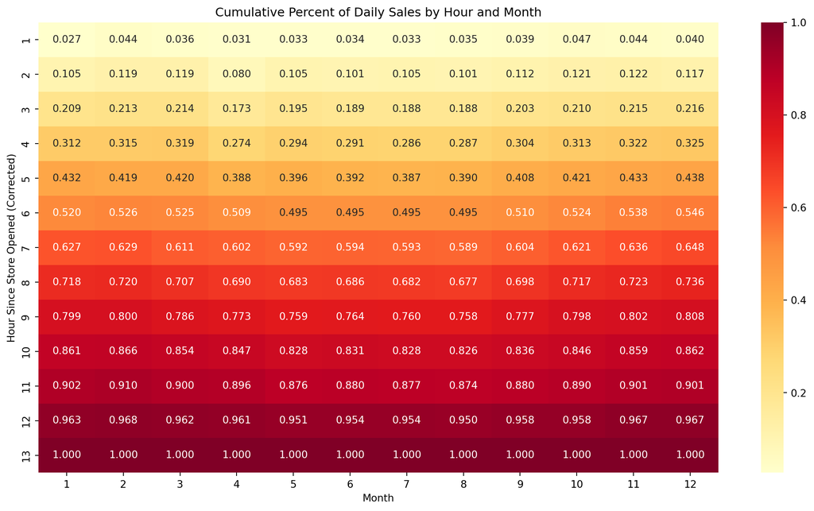

[output not shown]

```python
# Normalize the cumulative data so the last row equals 1.0 for each month


# Create heatmap with normalized cumulative percentages
plt.figure(figsize=(15, 8))

# Create pivot table with mean values
heatmap_data_mean = hourly_pct_pd.pivot_table(
    values="PCT_DAILY_SALES",
    index="HOURS_SINCE_OPEN_CORRECTED",
    columns="MONTH",
    aggfunc="mean",
)

# Calculate cumulative sum for each month (column)
cumulative_pct_data = heatmap_data_mean.cumsum(axis=0)
cumulative_pct_data_normalized = cumulative_pct_data.div(cumulative_pct_data.iloc[-1])
# Create heatmap with cumulative percentages
sns.heatmap(cumulative_pct_data_normalized, annot=True, fmt=".3f", cmap="YlOrRd")
plt.title("Cumulative Percent of Daily Sales by Hour and Month")
plt.xlabel("Month")
plt.ylabel("Hour Since Store Opened (Corrected)")
plt.show()

# Verify that the last row now equals 1 for each month
print("\nColumn totals (should all be 1.0):")
```

There is clearly a seasonality pattern with sales moving earlier in the day during the winter months. It’s very slight so it’s a discussion if this is worth the added complexity of maintaining multiple % Sales calculations or just using a single one.

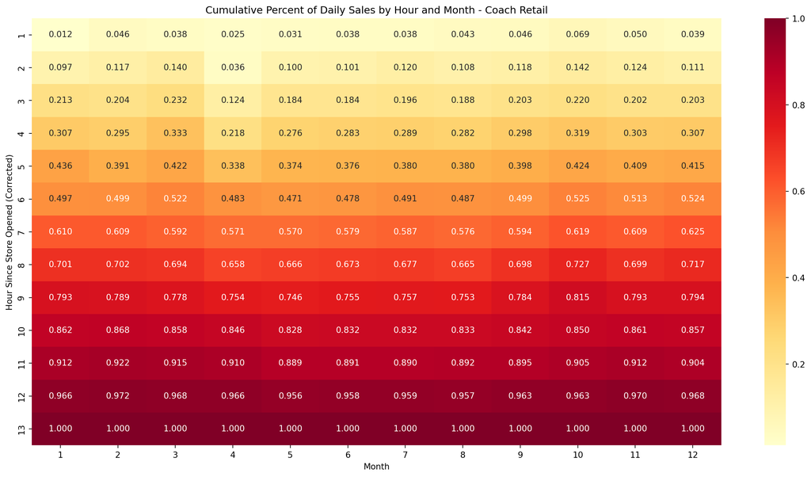

[output not shown]

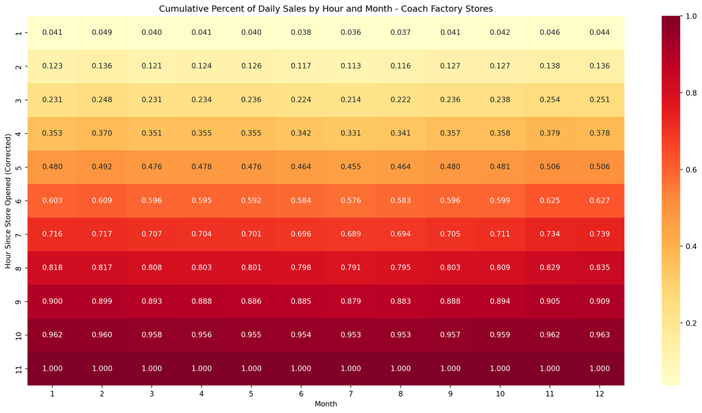

[output not shown]

```python
# Create heatmap with normalized cumulative percentages by CHNL_DESC
for channel in channels:
    channel_data = hourly_pct_pd[hourly_pct_pd["CHNL_DESC"] == channel]

    plt.figure(figsize=(15, 8))

    # Create pivot table with mean values
    heatmap_data_mean = channel_data.pivot_table(
        values="PCT_DAILY_SALES",
        index="HOURS_SINCE_OPEN_CORRECTED",
        columns="MONTH",
        aggfunc="mean",
    )

    # Calculate cumulative sum for each month (column)
    cumulative_pct_data = heatmap_data_mean.cumsum(axis=0)
    cumulative_pct_data_normalized = cumulative_pct_data.div(cumulative_pct_data.iloc[-1])

    # Create heatmap with cumulative percentages
    sns.heatmap(cumulative_pct_data_normalized, annot=True, fmt=".3f", cmap="YlOrRd")
    plt.title(f"Cumulative Percent of Daily Sales by Hour and Month - {channel}")
    plt.xlabel("Month")
    plt.ylabel("Hour Since Store Opened (Corrected)")
    plt.tight_layout()
    plt.show()

    # Verify that the last row now equals 1 for each month
    print(f"\n{channel} - Column totals (should all be 1.0):")
```

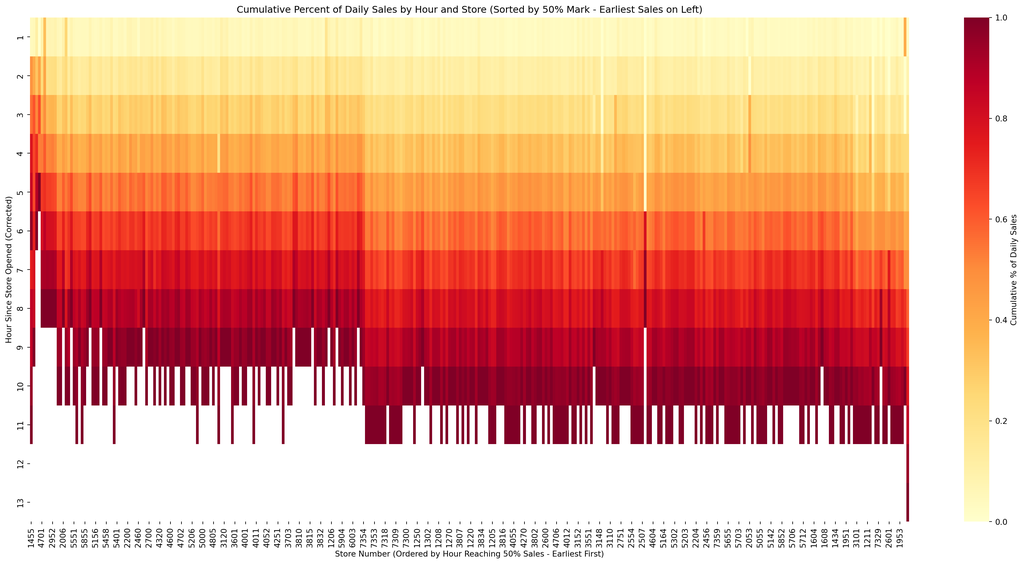

```python
# Heatmap: Cumulative percent sales by hour and store
plt.figure(figsize=(20, 10))

# Select a subset of stores for better visualization (e.g., 200 stores with most data)
top_stores = hourly_pct_pd.groupby("STORE_NUMBER").size().nlargest(400).index

# Filter data for top stores
filtered_data = hourly_pct_pd[hourly_pct_pd["STORE_NUMBER"].isin(top_stores)]

# Create pivot table with mean values
heatmap_data_by_store = filtered_data.pivot_table(
    values="PCT_DAILY_SALES",
    index="HOURS_SINCE_OPEN_CORRECTED",
    columns="STORE_NUMBER",
    aggfunc="mean",
)

# Calculate cumulative sum for each store (column), filling NaN with 0 first
cumulative_pct_by_store = heatmap_data_by_store.fillna(0).cumsum(axis=0)

# Normalize by the last non-zero value for each column
cumulative_pct_by_store_normalized = cumulative_pct_by_store.div(
    cumulative_pct_by_store.max(axis=0)
)

# Sort columns by the hour at which they reach 50% of daily sales (ascending = stores reaching 50% earliest on left)
pct_50_hour = (cumulative_pct_by_store_normalized >= 0.5).idxmax()
sorted_columns = pct_50_hour.sort_values(ascending=True).index
cumulative_pct_by_store_normalized = cumulative_pct_by_store_normalized[sorted_columns]

# Replace values >= 1.0 with NaN (except the first occurrence)
for col in cumulative_pct_by_store_normalized.columns:
    mask = cumulative_pct_by_store_normalized[col] >= 0.999
    if mask.any():
        first_100_idx = mask.idxmax()
        cumulative_pct_by_store_normalized.loc[first_100_idx + 1 :, col] = np.nan

# Create heatmap with cumulative percentages
sns.heatmap(
    cumulative_pct_by_store_normalized,
    annot=False,
    cmap="YlOrRd",
    cbar_kws={"label": "Cumulative % of Daily Sales"},
    vmin=0,
    vmax=1,
)
plt.title(
    "Cumulative Percent of Daily Sales by Hour and Store (Sorted by 50% Mark - Earliest Sales on Left)"
)
plt.xlabel("Store Number (Ordered by Hour Reaching 50% Sales - Earliest First)")
plt.ylabel("Hour Since Store Opened (Corrected)")
plt.xticks(rotation=90)
plt.tight_layout()
plt.show()
```

```python
hourly_pct_pd.head()
```

|  | BUSINESS_DATE | HOUR | MONTH | DAY_OF_WEEK | WEEK_OF_YEAR | STORE_NUMBER | PCT_DAILY_SALES | NET_SALES_AMOUNT_DLABS | HOURS_SINCE_OPEN_CORRECTED | CHNL_DESC |
| --- | --- | --- | --- | --- | --- | --- | --- | --- | --- | --- |
| 0 | 2023-01-02 | 10 | 1 | 1 | 1 | 1100 | 0.084037 | 485.00 | 1 | Coach Retail |
| 1 | 2023-01-02 | 11 | 1 | 1 | 1 | 1100 | 0.012866 | 74.25 | 2 | Coach Retail |
| 2 | 2023-01-02 | 12 | 1 | 1 | 1 | 1100 | -0.110461 | -637.50 | 3 | Coach Retail |
| 3 | 2023-01-02 | 13 | 1 | 1 | 1 | 1100 | 0.087070 | 502.50 | 4 | Coach Retail |
| 4 | 2023-01-02 | 14 | 1 | 1 | 1 | 1100 | 0.169807 | 980.00 | 5 | Coach Retail |

```python
# Add time of day bucket to hourly_pct_pd
hourly_pct_pd["TIME_OF_DAY"] = pd.cut(
    hourly_pct_pd["HOURS_SINCE_OPEN_CORRECTED"],
    bins=[0, 3, 6, 9, hourly_pct_pd["HOURS_SINCE_OPEN_CORRECTED"].max()],
    labels=["Morning", "Midday", "Evening", "Closing"],
    include_lowest=True,
)
```

```python
hourly_pct_pd
```

|  | BUSINESS_DATE | HOUR | MONTH | DAY_OF_WEEK | WEEK_OF_YEAR | STORE_NUMBER | PCT_DAILY_SALES | NET_SALES_AMOUNT_DLABS | HOURS_SINCE_OPEN_CORRECTED | CHNL_DESC | TIME_OF_DAY |
| --- | --- | --- | --- | --- | --- | --- | --- | --- | --- | --- | --- |
| 0 | 2023-01-02 | 10 | 1 | 1 | 1 | 1100 | 0.084037 | 485.00 | 1 | Coach Retail | Morning |
| 1 | 2023-01-02 | 11 | 1 | 1 | 1 | 1100 | 0.012866 | 74.25 | 2 | Coach Retail | Morning |
| 2 | 2023-01-02 | 12 | 1 | 1 | 1 | 1100 | -0.110461 | -637.50 | 3 | Coach Retail | Morning |
| 3 | 2023-01-02 | 13 | 1 | 1 | 1 | 1100 | 0.087070 | 502.50 | 4 | Coach Retail | Midday |
| 4 | 2023-01-02 | 14 | 1 | 1 | 1 | 1100 | 0.169807 | 980.00 | 5 | Coach Retail | Midday |
| ... | ... | ... | ... | ... | ... | ... | ... | ... | ... | ... | ... |
| 3273900 | 2026-02-17 | 18 | 2 | 2 | 8 | 7364 | 0.094963 | 687.49 | 9 | Coach Factory Stores | Evening |
| 3273901 | 2026-02-17 | 19 | 2 | 2 | 8 | 7364 | 0.124193 | 899.10 | 10 | Coach Factory Stores | Closing |
| 3273902 | 2026-02-17 | 20 | 2 | 2 | 8 | 7364 | 0.060174 | 435.63 | 11 | Coach Factory Stores | Closing |
| 3273903 | 2026-02-17 | 21 | 2 | 2 | 8 | 7364 | 0.010875 | 78.73 | 11 | Coach Factory Stores | Closing |
| 3273904 | 2026-02-17 | 23 | 2 | 2 | 8 | 7364 | -0.007955 | -57.59 | 11 | Coach Factory Stores | Closing |

3273905 rows × 11 columns

```python
grouped_pct_pd = (
    hourly_pct_pd.groupby(["STORE_NUMBER", "TIME_OF_DAY"])
    .agg({"NET_SALES_AMOUNT_DLABS": "sum"})
    .reset_index()
)
# Calculate percentage of daily sales for each store and time of day and round to 4 decimals
grouped_pct_pd["PCT_DAILY_SALES"] = grouped_pct_pd[
    "NET_SALES_AMOUNT_DLABS"
] / grouped_pct_pd.groupby("STORE_NUMBER")["NET_SALES_AMOUNT_DLABS"].transform("sum")
grouped_pct_pd["PCT_DAILY_SALES"] = grouped_pct_pd["PCT_DAILY_SALES"].round(4)
grouped_pct_pd.head()
```

|  | STORE_NUMBER | TIME_OF_DAY | NET_SALES_AMOUNT_DLABS | PCT_DAILY_SALES |
| --- | --- | --- | --- | --- |
| 0 | 1100 | Morning | 2209969.52 | 0.1743 |
| 1 | 1100 | Midday | 4589746.54 | 0.3619 |
| 2 | 1100 | Evening | 4005400.10 | 0.3158 |
| 3 | 1100 | Closing | 1876978.80 | 0.1480 |
| 4 | 1101 | Morning | 1074560.01 | 0.1943 |

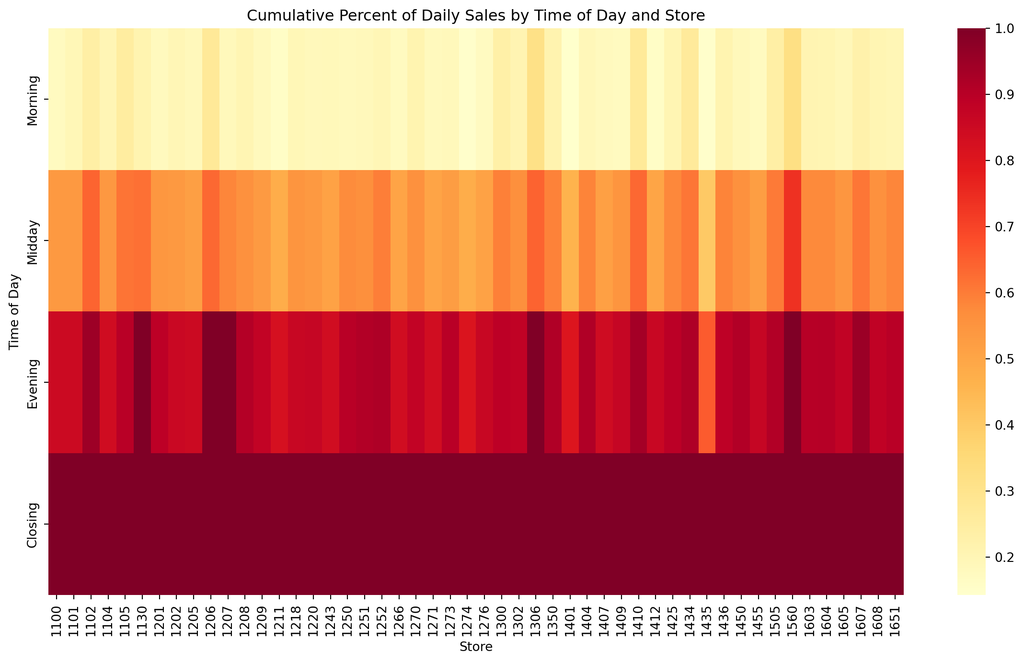

```
Average percent of sales by time of day:
TIME_OF_DAY
Morning    0.202354
Midday     0.357026
Evening    0.328800
Closing    0.111806
dtype: float64
```

```python
# Create pivot table with mean values by time of day and store
top_stores = grouped_pct_pd.groupby("STORE_NUMBER").size().nlargest(50).index
filtered_data = grouped_pct_pd[grouped_pct_pd["STORE_NUMBER"].isin(top_stores)]

heatmap_data_tod = filtered_data.pivot_table(
    values="PCT_DAILY_SALES",
    index="TIME_OF_DAY",
    columns="STORE_NUMBER",
    aggfunc="mean",
)

# Create heatmap with time of day buckets
plt.figure(figsize=(15, 8))

# Calculate cumulative sum for each store (column)
cumulative_pct_tod = heatmap_data_tod.cumsum(axis=0)
cumulative_pct_tod_normalized = cumulative_pct_tod.div(cumulative_pct_tod.iloc[-1])

# Create heatmap with cumulative percentages
sns.heatmap(cumulative_pct_tod_normalized, annot=False, fmt=".3f", cmap="YlOrRd")
plt.title("Cumulative Percent of Daily Sales by Time of Day and Store")
plt.xlabel("Store")
plt.ylabel("Time of Day")
plt.show()

print("\nAverage percent of sales by time of day:")
print(heatmap_data_tod.mean(axis=1))
```